# Analyse de l'activité d'un Hôpital

Ligne 34 remplacer **Wis* par l'hôpital de son choix.

```r
source("../prologue.R")
```

[output not shown]

```
## [1] "Fichier courant: rpu2013d0112.Rda"
```

```r
source("../../../Routines/mes_fonctions.R")

date()
```

```
## [1] "Tue Jun 17 22:17:04 2014"
```

```r
pt <-nrow(d1)
# population totale
pt
```

```
## [1] 344073
```

### Population totale 344073

# Récupération des données

```r
library("epicalc")
library("lubridate")
library("stargazer")
source("odds.R")

# Pour supprimer la notation scientifique:
options(scipen = 6, digits = 2)

# Pour imposer un péparateur de milliers:
knit_hooks$set(inline = function(x) {
  prettyNum(x, big.mark=" ")
})

ch <- "3Fr"
ch.names <- "Clinique des 3 frontières - 2013"

hopital<-d1[d1$FINESS == ch,]
n <- nrow(hopital)
```

# CH de Clinique des 3 frontières - 2 013

### Passages en 2013: 15 688

## Mode de sortie

- 4 items: mutation, Transfert, Domicile, décès
- **hosp** nombre total de patients hospitalisés
- **total** hospitalisés + retour à domicile
- le rapport des deux donne le **taux d'hospitalisation**

```r
a<-summary(hopital$MODE_SORTIE)
a
```

```
##        NA  Mutation Transfert  Domicile     Décès      NA's
##         0       236        19     14275         0      1158
```

```r
hosp <- as.numeric(a["Mutation"] + a["Transfert"])
hosp
```

```
## [1] 255
```

```r
total <- as.numeric(hosp + a["Domicile"])
total
```

```
## [1] 14530
```

```r
ratio_hosp <- round(hosp * 100 / as.numeric(a["Domicile"]))
ratio_hosp
```

```
## [1] 2
```

```r
tx_hosp <- round(hosp * 100 / total)
tx_hosp
```

```
## [1] 2
```

```r
stargazer(table(hopital$MODE_SORTIE))
```

```
## Error: $ operator is invalid for atomic vectors
```

```r
tab1(hopital$MODE_SORTIE, main="Mode de sortie de l'hôpital")
```

```
## hopital$MODE_SORTIE :
##           Frequency   %(NA+)   %(NA-)
## NA                0      0.0      0.0
## Mutation        236      1.5      1.6
## Transfert        19      0.1      0.1
## Domicile      14275     91.0     98.2
## Décès             0      0.0      0.0
## NA's           1158      7.4      0.0
##   Total       15688    100.0    100.0
```

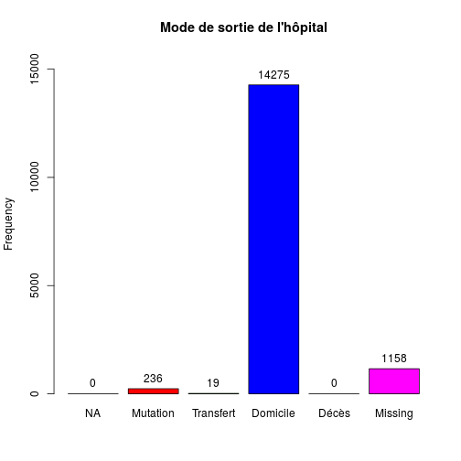

```
## hopital$MODE_SORTIE :
##           Frequency   %(NA+)   %(NA-)
## NA                0      0.0      0.0
## Mutation        236      1.5      1.6
## Transfert        19      0.1      0.1
## Domicile      14275     91.0     98.2
## Décès             0      0.0      0.0
## NA's           1158      7.4      0.0
##   Total       15688    100.0    100.0
```

```r
tab1(hopital$MODE_SORTIE, main="Mode de sortie de l'hôpital")
```

- Nombre de patients hospitalisés (mutation + transferts): 255
- Taux d'hospitalisation: **2 %**

## Destination

- 6 items: MCO, SSR, SLD, PSY, HAD, HMS
- on détermine les vrais non renseignés par soustraction entre le nombre total de patients déclarés hospitalisés (**hosp**) et la somme des 6 items qui décrivent la ventilation des hospitalisés. Normalement cette différence devrait être nulle.
- cette différence est notée **delta**. Elle permet de calculer l'exhaustivité pour l'item destination **exhaustivite.destination**

```r
a<-summary(hopital$DESTINATION)
a
```

```
   NA   MCO   SSR   SLD   PSY   HAD   HMS  NA's
    0   251     0     0     4     0     0 15433
```

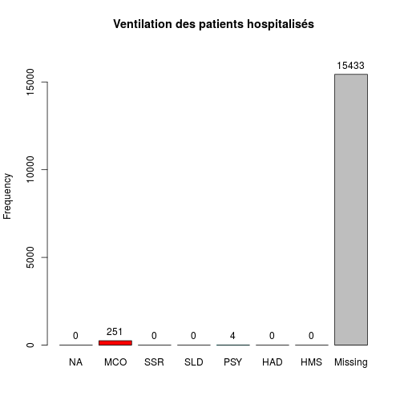

```
hopital$DESTINATION :
        Frequency   %(NA+)   %(NA-)
NA              0      0.0      0.0
MCO           251      1.6     98.4
SSR             0      0.0      0.0
SLD             0      0.0      0.0
PSY             4      0.0      1.6
HAD             0      0.0      0.0
HMS             0      0.0      0.0
NA's        15433     98.4      0.0
  Total     15688    100.0    100.0
```

```r
# delta = vrai non renseignés
delta <- hosp - a["MCO"]-a["SSR"]-a["SLD"]-a["PSY"]-a["HAD"]-a["HMS"]
# exhaustivité réelle pour la destination
exhaustivite.destination <- round(100-(delta*100/hosp),2)

tab1(hopital$DESTINATION, main="Ventilation des patients hospitalisés")
```

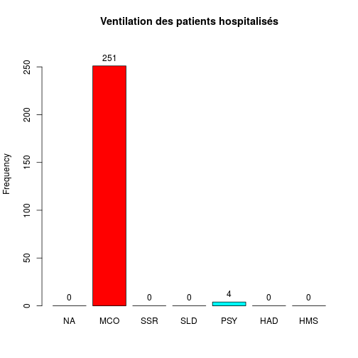

```
hopital$DESTINATION :
        Frequency   %(NA+)   %(NA-)
NA              0      0.0      0.0
MCO           251      1.6     98.4
SSR             0      0.0      0.0
SLD             0      0.0      0.0
PSY             4      0.0      1.6
HAD             0      0.0      0.0
HMS             0      0.0      0.0
NA's        15433     98.4      0.0
  Total     15688    100.0    100.0
```

```r
tab1(hopital$DESTINATION, main="Ventilation des patients hospitalisés", missing=FALSE)
```

Distribution intra-hospitalière des patients hospitalisés. La colonne *Missing* correspond aux patients non hospialisés.

- vrai non renseignés pour la destination: 0, exhaustivité: 100 %

## Orientation

- 13 items: CHIR FUGUE HDT HO MED OBST PSA REA REO SC SCAM SI UHCD
  - items hospitalisation (**orient.hosp**): CHIR, HDT, HO, MED, OBST, REA, SC, SI, UHCD
  - sorties atypiques (**orient.atypique**): FUGUE, PSA, SCAM
  - réorientation immédiate (**orient.reorient **): REO
- L'orientation est un mélange d'hospitalisés et de non hospitalisés.
- L'exhaustivité (**orient.exhaustivite**) est calculée comme le rapport entre les orientation correspondant à une hospitalisation (MED, CHIR, SI, etc) et le nombre d'hospitalisations (**hosp**) déclarées au paragraphe destination. Comment calculer l'exhaustivité des sorties atypiques ?

```r
a <- summary(hopital$ORIENTATION)
a
```

```
 CHIR FUGUE   HDT    HO   MED  OBST   PSA   REA   REO    SC  SCAM    SI
    5    11     1     5     2     0    91     1    69     1     4     1
 UHCD  NA's
    1 15496
```

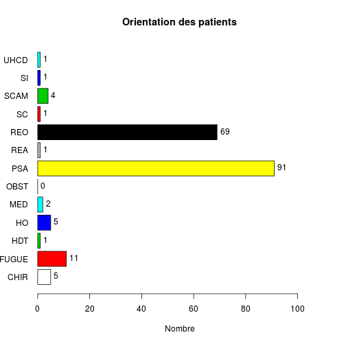

```
a :
        Frequency Percent Cum. percent
CHIR            5     2.6          2.6
FUGUE          11     5.7          8.3
HDT             1     0.5          8.9
HO              5     2.6         11.5
MED             2     1.0         12.5
OBST            0     0.0         12.5
PSA            91    47.4         59.9
REA             1     0.5         60.4
REO            69    35.9         96.4
SC              1     0.5         96.9
SCAM            4     2.1         99.0
SI              1     0.5         99.5
UHCD            1     0.5        100.0
  Total       192   100.0        100.0
```

```r
#on supprime les NA
a<-hopital$ORIENTATION[!is.na(hopital$ORIENTATION)]
nb_orient <- length(a)
tab1(a,horiz=T,main="Orientation des patients",xlab="Nombre")
```

```r
sa <- summary(a)
orient.hosp <- as.numeric(sa["HO"]+sa["HDT"]+sa["UHCD"]+sa["SI"]+sa["SC"]+sa["REA"]+sa["OBST"]+sa["MED"]+sa["CHIR"])
orient.atypique <- as.numeric(sa["SCAM"]+sa["PSA"]+sa["FUGUE"])
orient.reorient <- as.numeric(sa["REO"])
orient.exhaustivite <- 100-round(100*(hosp - orient.hosp)/hosp,2)
```

- nombre de RPU avec orientation renseigné: 192
- nombre d'orientation correspondant à une hospitalisation: 17
- nombre de patients déclarés hospitalisés à la rubrique destination: 255
- exhaustivité: **6.7 %**
- nombre de réorientations: 69
- nombre de sorties atypiques: 106

## Age

```r
age_local<-hopital$AGE
s <- summary(age_local)

c <- cut(age_local,breaks=c(-1,1,75,150),labels=c("1 an","1 à 75 ans","sup 75 ans"),ordered_result=TRUE)
a <- summary(c)
a
```

```
##       1 an 1 à 75 ans sup 75 ans       NA's
##        436      13641       1606          5
```

```r
c2 <- cut(age_local, breaks = c(-1,19,75,120), labels = c("Pédiatrie","Adultes","Gériatrie"))
b <- summary(c2)
b
```

```
## Pédiatrie   Adultes Gériatrie      NA's
##      3857     10220      1606         5
```

### Age moyen: 39 ans

### Pédiatrie: 3 857 (25 %)

### Gériatrie: 1 606 (10 %)

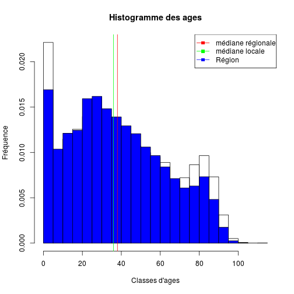

```r
# region: chiffre pour toute l'Alsace
# local: hopital
region<-d1$AGE

hist(region,freq=F,main="Histogramme des ages", ylab="Fréquence", xlab="Classes d'ages")
hist(age_local, add=T,col="blue",freq=F)
abline(v=median(region,na.rm=T),col="red")
abline(v=median(s,na.rm=T),col="green")
legend("topright",legend=c("médiane régionale","médiane locale","Région"),col=c("red","green","blue"),lty=1, pch=15)
```

```r
# moins de 1 an / total, pt = total RPU pour la région

local<-hopital$AGE[hopital$AGE < 1]
length(local)
```

```
## [1] 194
```

```r
length(local) * 100 /n
```

```
## [1] 1.2
```

```r
region<-d1$AGE[d1$AGE < 1]
length(region) * 100 / pt
```

```
## [1] 2.7
```

```r
# on forme une matrice carrée de 2 lignes et 2 colonnes:
# on saisi d'abord la colonne 1, puis 2
# pour une saisie par ligne mettre byrow=TRUE
M1 <- matrix(c(length(local),n,length(region),pt), nrow = 2,byrow=FALSE)
M1
```

```
##       [,1]   [,2]
## [1,]   194   9243
## [2,] 15688 344073
```

```r
chisq.test(M1)
```

```
##
##  Pearson's Chi-squared test with Yates' continuity correction
##
## data:  M1
## X-squared = 118, df = 1, p-value < 2.2e-16
```

```r
p<-M1[1,1]/n
q<-M1[1,2]/pt
or<-p*(1-q)/q*(1-p)
p
```

```
## [1] 0.012
```

```r
q
```

```
## [1] 0.027
```

```r
or
```

```
## [1] 0.44
```

```r
calcOddsRatio(M1,referencerow=2)
```

```
## [1] "categorie =  , odds ratio =  0.460332661849261"
## [1] "categorie =  ,  95 % interval de confiance = [ 0.398961775549369 , 0.531144015672759 ]"
```

```r
calcRelativeRisk(M1)
```

```
## [1] "category =  , relative risk =  0.471426808675715"
## [1] "category =  ,  95 % confidence interval = [ 0.409797140272724 , 0.54232500448945 ]"
```

```r
# 75 ans et plus

local <- hopital$AGE[hopital$AGE > 74]
length(local) * 100 /n           # % de la pop locale de 75 ans qui passa au SU
```

```
## [1] 11
```

```r
region<-d1$AGE[d1$AGE > 74]
length(region) * 100 / pt    # % de 75 ans dans la pop alsacienne qui consulte au SU
```

```
## [1] 15
```

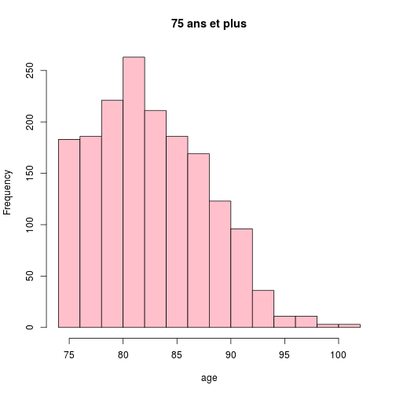

```r
hist(local,main="75 ans et plus",xlab="age",col="pink")
```

```r
summary(local)
```

```
##    Min. 1st Qu.  Median    Mean 3rd Qu.    Max.    NA's
##      75      79      82      83      87     102       5
```

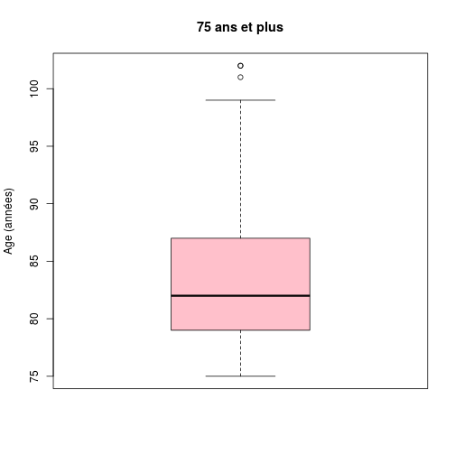

```r
boxplot(local,col="pink",main="75 ans et plus",ylab="Age (années)")
```

```r
# calcul manuel de l'odds-ratio

M1 <- matrix(c(length(local),n-length(local),length(region),pt-length(region)), nrow = 2,byrow=FALSE)
M1
```

```
##       [,1]   [,2]
## [1,]  1707  53081
## [2,] 13981 290992
```

```r
chisq.test(M1)
```

```
##
##  Pearson's Chi-squared test with Yates' continuity correction
##
## data:  M1
## X-squared = 240, df = 1, p-value < 2.2e-16
```

```r
p<-M1[1,1]/n
q<-M1[1,2]/pt
or<-(p*(1-q))/(q*(1-p))
p
```

```
## [1] 0.11
```

```r
q
```

```
## [1] 0.15
```

```r
or
```

```
## [1] 0.67
```

```r
# calcul del'OR et du risque relatif avec formules:

calcOddsRatio(M1,referencerow=2)
```

```
## [1] "categorie =  , odds ratio =  0.669325296198132"
## [1] "categorie =  ,  95 % interval de confiance = [ 0.635984819796526 , 0.704413593195583 ]"
```

```r
calcRelativeRisk(M1)
```

```
## [1] "category =  , relative risk =  0.67962794859263"
## [1] "category =  ,  95 % confidence interval = [ 0.646856315947749 , 0.71405988798529 ]"
```

```r
chisq.test(M1)
```

```
##
##  Pearson's Chi-squared test with Yates' continuity correction
##
## data:  M1
## X-squared = 240, df = 1, p-value < 2.2e-16
```

```r
fisher.test(M1)
```

```
##
##  Fisher's Exact Test for Count Data
##
## data:  M1
## p-value < 2.2e-16
## alternative hypothesis: true odds ratio is not equal to 1
## 95 percent confidence interval:
##  0.64 0.70
## sample estimates:
## odds ratio
##       0.67
```

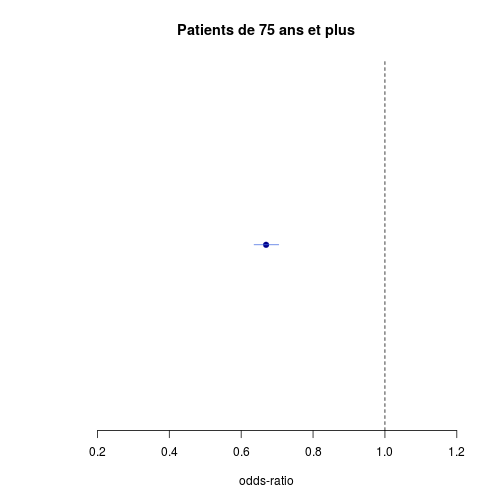

```r
# graphe de l'OR

odds <- calcOddsRatio(M1,referencerow=2,quiet=TRUE)
or <- odds[1]
lower <- odds[2]
upper <- odds[3]
y <- 0.5
if(lower > 1) limiteInf <- 0.5 else limiteInf <- lower - 0.5
plot(or,y,pch=19,col="darkblue",xlab="odds-ratio", ylab="",axes=FALSE,main="Patients de 75 ans et plus",xlim=c(limiteInf,upper+0.5))
axis(1)
abline(v=1, lty="dashed")
lines(c(lower,upper),c(y,y),col="royalblue")
```

## sex ratio

```r
sexew <- hopital$SEXE
local <- summary(sexew)
local
```

```
##    F    I    M
## 7445    0 8243
```

```r
srw <- round(local[3]/local[1],3)

sexer <- d1$SEXE
region <- summary(sexer)
region
```

```
##      F      I      M
## 163818      5 180250
```

```r
srr <- round(region[3]/region[1],3)

M1<-matrix(c(local[3],local[1],region[3],region[1]),nrow=2)
colnames(M1) <- c("Local","Alsace")
rownames(M1) <- c("Hommes","Femmes")
M1
```

```
##        Local Alsace
## Hommes  8243 180250
## Femmes  7445 163818
```

```r
calcOddsRatio(M1,referencerow=2)
```

```
## [1] "categorie = Hommes , odds ratio =  1.00625243389107"
## [1] "categorie = Hommes ,  95 % interval de confiance = [ 0.974520007349746 , 1.03901813515903 ]"
```

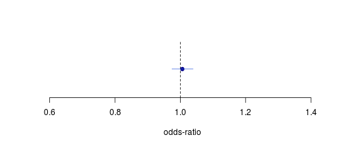

```r
or <- calcOddsRatio(M1,referencerow=2,quiet=TRUE)

plot(or[1],1,pch=19,col="darkblue",xlab="odds-ratio", ylab="",axes=FALSE)
axis(1)
abline(v=1, lty="dashed")
lines(c(or[2],or[3]),c(1,1),col="royalblue")
```

sex-ratio local = 1.1  
sex-ratio régional = 1.1  
odds-ratio = 1 [0.97-1]

## Horaires

```r
e<-hour(hopital$ENTREE)
a<-cut(e,breaks=c(0,7,19,23),labels=c("nuit profonde","journée","soirée"))
b <- summary(a)
```

### Soirée 17 %

### Nuit profonde 10 %

On fait la somme du vendredi 20 heures au lundi matin 8 heures. Dimanche = 1

```r
d <-  hopital$ENTREE[wday(hopital$ENTREE)==1 | wday(hopital$ENTREE)==7 | (wday(hopital$ENTREE)==6 & hour(hopital$ENTREE)>19) | (wday(hopital$ENTREE)==2 & hour(hopital$ENTREE)<8)]
f<-summary(as.factor(wday(d)))
```

### Week-end: 5 549 dossiers (35 %)

## Gravité

```r
d <-  hopital$GRAVITE
a <- summary(d)
```

### CCMU 1: 1 431 (9 %)

### CCMU 4 & 5: 18 (0 %)

## Durée de prise en charge

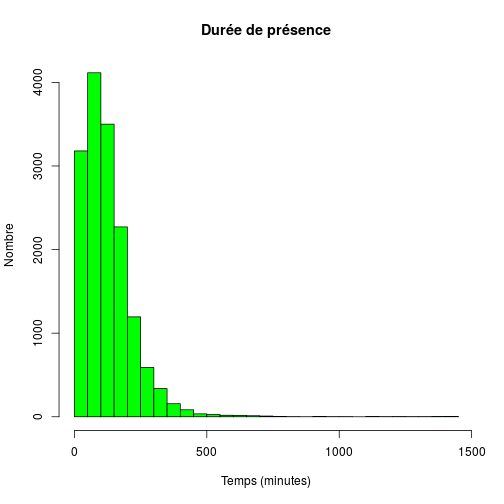

```r
e<-ymd_hms(hopital$ENTREE)
s<-ymd_hms(hopital$SORTIE)

hopital$presence <- s - e
hopital$presence[d1$presence < 0]<-NA

#  hopital$presence est de type "difftime" est peut s'exprimer en minutes ou en secondes. Si nécessaire on convertit les secondes en minutes:
if(units(hopital$presence) == "secs")
  hopital$presence <- hopital$presence/60

a <- summary(as.numeric(hopital$presence))

# on limite la durée de présence limitée à 1 jours
troisJours <- hopital[as.numeric(hopital$presence) < 1440 * 1, "presence"]
hist(as.numeric(troisJours),breaks=40,main="Durée de présence",xlab="Temps (minutes)",ylab="Nombre",col="green")
```

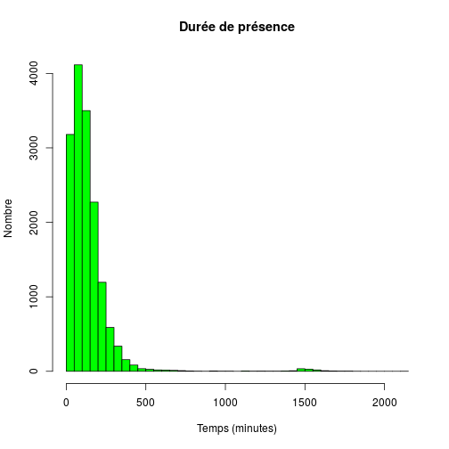

```r
# histogramme avec toutes les données:
hist(as.numeric(hopital$presence),breaks=40,main="Durée de présence",xlab="Temps (minutes)",ylab="Nombre",col="green")
```

```r
q <- hopital$presence[as.numeric(hopital$presence) < 4*60]
h <- hopital[hopital$MODE_SORTIE=="Mutation" | hopital$MODE_SORTIE=="Transfert","presence"]
sh <- summary(as.numeric(h))
sh
```

```
##    Min. 1st Qu.  Median    Mean 3rd Qu.    Max.    NA's
##       1      40     108     126     174    1410    1158
```

```r
dom <- hopital[hopital$MODE_SORTIE=="Domicile","presence"]
sdom <- summary(as.numeric(dom))
```

## TOP 5 des pathologies

### Traumatiques

```r
trauma<-hopital[substr(hopital$DP,1,3) >= "S00" & substr(hopital$DP,1,4) <="T65",]
head(trauma$DP)
```

```
## [1] "S018" "T140" "S010" "S610" NA     NA
```

```r
t <- summary(as.factor(trauma$DP))
head(sort(t,decreasing=T),6)
```

```
##    NA's (Other)    S934    S619    S019    S009
##    1912     718     371     327     273     195
```

# Exhaustivité des données (RADAR)

Par défaut, le diagramme en radar commence à 15h et progresse dans le sens antihoraire (la position 2 correspond à 14 heures, etc.)

Dessin de deux graphiques radar superposés, l'un pour l'ensemble des rpu de la région, l'autre pour l'hôpital considéré.  
On défini dans la variable *rpu.names* le nom et l'ordre des variables à afficher. Le radar commence par défaut à 15h puis progresse en sens anti-horaire. Les variables sont divisées en 3 secteurs:

- l'entrée du patient
- le diagnostic médical
- la sortie  
  Le taux de complétude est calculé à partir des items non reseignés (NA) en appliquant à chaque colonne la fonction *mean* qui retourne le pourcentage de NA.

[figure not shown]

```r
library("plotrix")
library("openintro")

rpu.names <- c("Entrée","Sexe","Age","Commune","ZIP","Provenance","PEC Transport","Mode Transport","Mode entrée","CCMU","Motif","DP","Sortie", "Mode sortie","Orientation","Destination")

# taux de complétude régional
# ---------------------------
a <- is.na(d1) # matrice équivalente à d1 formée uniquement de TRUE et FALSE
b <- round(apply(a, 2, mean) * 100, 2) # pour chaque coonne de la matrice a on calcule le taux de NA's
b <- cbind(b) # le vecter ligne est transformé en colonne
colnames(b)<-"% de NA's" # l'intitulé de la coonne
# on réarrange b pour que l'ordre des items soit cohérent avec rpu.names. Le tout est sauvegardé sous le nom de complétude
completude <- c(b[6],b[16],b[20],b[3],b[2],b[15],b[19],b[18],b[10],b[9],b[12],b[5],b[17],b[11],b[14],b[4])
completude <- 100 - completude

radial.plot(completude, labels = rpu.names, ,rp.type="p", radial.lim =c(0,100),  poly.col = fadeColor("khaki",fade = "A0"), main=paste(ch.names,"- Taux de complétude des RPU"), radial.labels=c("0","20%","40%","60%","80%",""), boxed.radial=FALSE, line.col="khaki", label.prop=0)

# taux de complétude de l'hôpital local
# -------------------------------------
a<-is.na(hopital)
b<-round(apply(a,2,mean)*100,2)
#b<-sort(b)
b<-cbind(b)
colnames(b)<-"%"
completude_hop <- c(b[6],b[16],b[20],b[3],b[2],b[15],b[19],b[18],b[10],b[9],b[12],b[5],b[17],b[11],b[14],b[4])
completude_hop <- 100 - completude_hop
# corrections
completude_hop[16] <- exhaustivite.destination
completude_hop[15] <- orient.exhaustivite

radial.plot(completude_hop, labels = rpu.names , radial.lim =c(0,100), add=T,rp.type="p", line.col="goldenrod4", main="Taux de complétude des RPU", lwd=2)

legend("bottomleft", legend=c(ch.names,"Alsace"), col=c("goldenrod4","khaki"), lty=1, bty="n", pch=15)
```

```r
c <- as.data.frame( completude)
rownames(c) <- rpu.names
c <- cbind(c, completude_hop)
names(c) <- c("Alsace (%)", ch.names)
c
```

```
##                Alsace (%) Clinique des 3 frontières - 2013
## Entrée                100                           100.00
## Sexe                  100                           100.00
## Age                   100                            99.97
## Commune               100                           100.00
## ZIP                   100                           100.00
## Provenance             64                             0.22
## PEC Transport          74                            17.23
## Mode Transport         77                            99.88
## Mode entrée            90                            83.71
## CCMU                   86                            96.46
## Motif                  64                             7.22
## DP                     66                            87.81
## Sortie                 91                           100.00
## Mode sortie            86                            92.62
## Orientation            20                             6.67
## Destination            21                           100.00
```

# Utilsation des routines

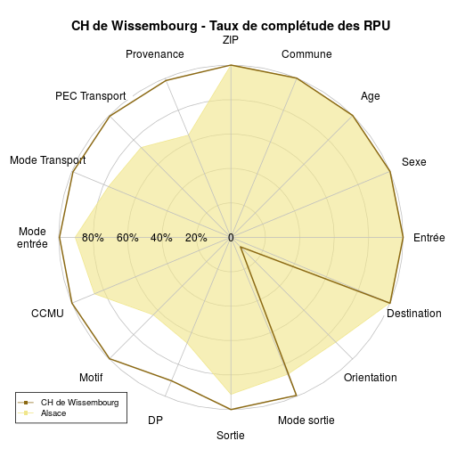

```r
source("../../../Routines/mes_fonctions.R")

ch <- "Wis"
ch.names <- "CH de Wissembourg"
hopital<-d1[d1$FINESS == ch,]

x <- completude(d1)
y <- completude(hopital)
radar_completude(x,y, ch.names)
```

## Application: création de radars de complétude pour tous les hôpitaux:

```r
#par(mar=c(2,6,4,2), oma=c(1,4,1,1))
x <- completude(d1)
for(i in 1:length(hop.short)){
  ch.names <- hop.long[i]
  ch <- hop.short[i]
  hopital <- d1[d1$FINESS == ch,]
  y <- completude(hopital)
  radar_completude(x,y, ch.names)
}
```

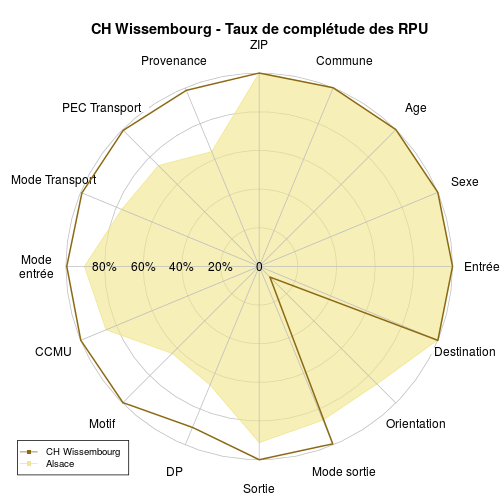

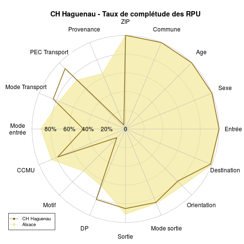

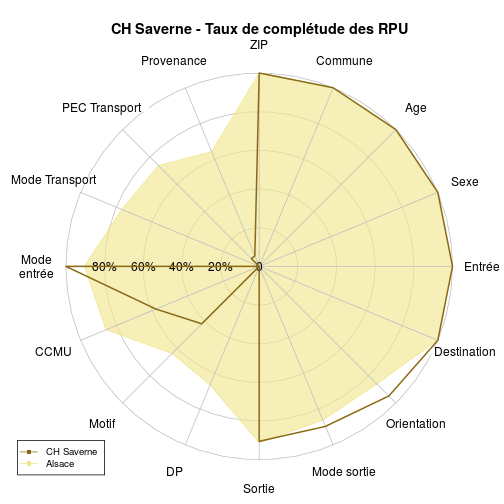

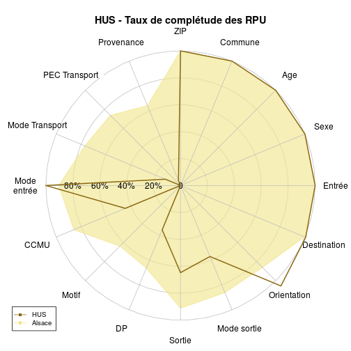

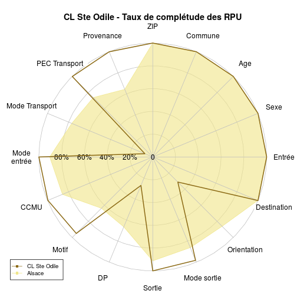

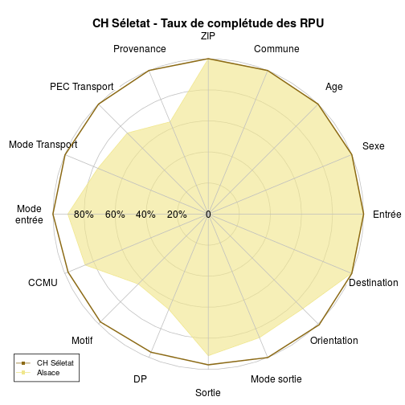

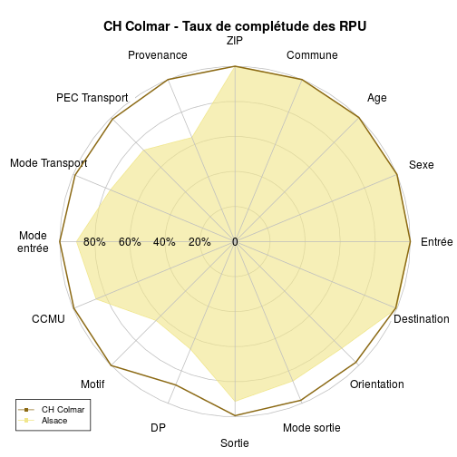

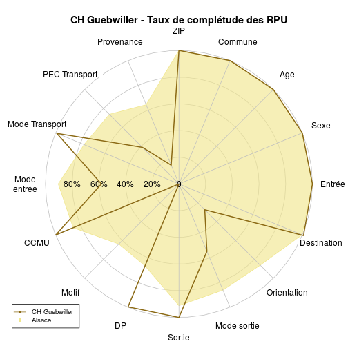

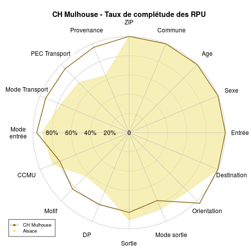

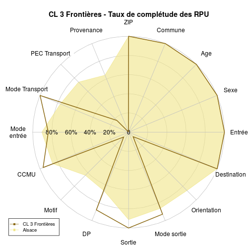

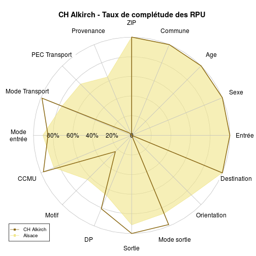

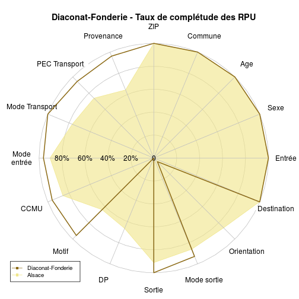

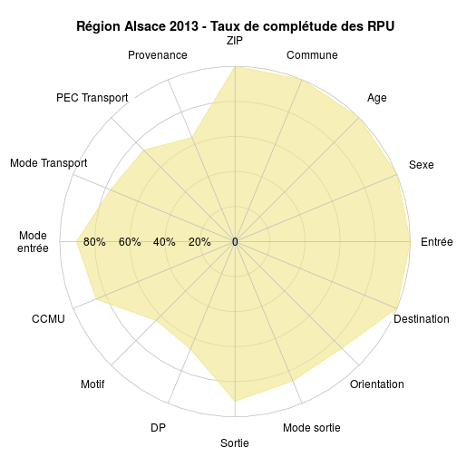

```r
radar_completude(x, ch.names="Région Alsace 2013")
```

```r
par(mar=c(5, 4, 4, 2) + 0.1, oma=c(0,0,0,0))
```